# Hotels and Booking Cancellations

Ana Imam, Jihan Khandaker, Supreet Nirman, Al Shumyatcher, Mihir Zaveri

February 21st, 2021

## Introduction

In this project, we are utilizing the data set of hotel bookings to address the problem of cancellations. This is an important issue for hotels from a business standpoint, as cancellations result in a loss of potential revenue and limit the optimization of the hotel’s service levels. Our analyses of this data set are aimed to help the management teams of both the City Hotel and Resort Hotel to better predict the likelihood of cancellation. With this, the hotels can then employ an overbooking method that can optimize the capacity-based revenue management.

#### Approach

In approaching this data set, we will first separate the data for the City Hotel and the Resort Hotel. For both hotels, we have narrowed down a number of booking features that we believe have a significant correlation with the probability of cancellation. From this, we have developed a profile of probabilities that can be applied to any future bookings. Hotels can then use this profile to calculate the cancellation probability of future bookings and consider the option of overbooking.

#### Data Set-up

```r
hotels <- read.csv("hotel_bookings.csv")
rhotels <- hotels[hotels$hotel == "Resort Hotel",]
chotels <- hotels[hotels$hotel == "City Hotel",]
library(ggplot2)
# install.packages(gridExtra)
library(gridExtra)
```

### Graph Set-up and Design

```r
weekend_cancellations_by_hotel <- function(name = "HOTEL"){
  ifelse(name == "City", hot <- chotels, hot <- rhotels)
  a <- as.data.frame( table( hot$stays_in_weekend_nights, hot$is_canceled ) )
  a <- as.data.frame( cbind.data.frame( a[1:(nrow(a)/2),1],
                                        a[1:(nrow(a)/2),3],
                                        a[(nrow(a)/2+1):nrow(a),3] )
                      )
  colnames(a) <- c("Weekends", "NotCanceled", "Canceled")
  a$percentCanceled <- a$Canceled / (a$Canceled + a$NotCanceled)
  a <- a[a$Canceled + a$NotCanceled >= 10, ]
  a <- tapply( a$percentCanceled, a$Weekends, mean, na.rm = TRUE )
  #the pretty colors serve as but a temporary repreive from the torture that is trying to write code in R
  barplot( a[!is.na(a)] , xlab = "Weekend Nights", ylab = "Cancellation Probability", main = paste(name, "Hotel"), axis.lty=1, ylim = c(0,0.8), col = rgb(255 * a[!is.na(a)], 225 * (1-a[!is.na(a)]), 0, maxColorValue = 255))


}
```

```r
weeknight_cancellations_by_hotel <- function(name = "HOTEL"){
  ifelse(name == "City", hot <- chotels, hot <- rhotels)
  a <- as.data.frame( table( hot$stays_in_week_nights, hot$is_canceled ) )
  a <- as.data.frame( cbind.data.frame( a[1:(nrow(a)/2),1],
                                        a[1:(nrow(a)/2),3],
                                        a[(nrow(a)/2+1):nrow(a),3] )
                      )
  colnames(a) <- c("Weeknights", "NotCanceled", "Canceled")
  a$percentCanceled <- a$Canceled / (a$Canceled + a$NotCanceled)
  a <- a[a$Canceled + a$NotCanceled >= 10, ]
  a <- tapply( a$percentCanceled, a$Weeknights, mean, na.rm = TRUE )
  barplot( a[!is.na(a)] , xlab = "Week Nights", ylab = "Cancellation Probability", main = paste(name, "Hotel"), axis.lty=1, ylim = c(0,0.8), col = rgb(255 * a[!is.na(a)], 225 * (1-a[!is.na(a)]), 0, maxColorValue = 255))


}
```

```r
week_end_colorPlot <- function(name, x = hotels, probabilityLimit = 9001, minNumber = 30){

  ifelse(name == "City Hotel", x <- chotels, x<- rhotels)

  x$ones <- 1

  a <- aggregate(is_canceled ~ stays_in_week_nights + stays_in_weekend_nights, data = x, mean, na.rm = TRUE)
  onesFrame <- aggregate(ones ~ stays_in_week_nights + stays_in_weekend_nights, data = x, sum, na.rm = TRUE)

  filteredA <- cbind(a[,1][onesFrame$ones > minNumber][a$is_canceled < probabilityLimit],
                     a[,2][onesFrame$ones > minNumber][a$is_canceled < probabilityLimit],
                     a[,3][onesFrame$ones > minNumber][a$is_canceled < probabilityLimit]
                     )

  colnames(filteredA) <- c("stays_in_week_nights", "stays_in_weekend_nights", "Canceled")
  filteredA <- as.data.frame( filteredA[complete.cases(filteredA), ] )

  qplot(filteredA$stays_in_week_nights,
        filteredA$stays_in_weekend_nights,
        color = filteredA$Canceled,
        size = I(12),
        geom = "point",
        alpha = I(0.85),
        xlab = "Stays in Week Nights",
        ylab = "Stays in Weekend Nights") +

    scale_color_gradient(
      limits = c(0, ceiling( max(filteredA$Canceled) / 0.2) * 0.2),
      low = "green", high = "red",
      name = "Cancellation Probability") +

    ggtitle(paste("Cancellation Probability as a Function of Number\n of Week and Weekend Nights for", name)) +

    theme( plot.title = element_text( hjust = 0.5 ) ) +
    theme( panel.grid.minor = element_blank() ) +
    theme_bw()

}
```

## Variable Omission

This data set provides information on many of the different features of hotel bookings. However, we have realized that not every variable has the potential of predicting cancellation probabilities, and thus, have been omitted:

**Arrival_date_year**: Since these are the years of the recorded bookings, they are not predictive of bookings in future years

**Arrival_date_week_number** & **Arrival_date_day_of_month**: These variables both have excessive variation and are also unnecessary given the analysis of the arrival months of the bookings

**adults**: as shown below, this feature lacks variability in both hotel populations, so it cannot be predictive of cancellations

```r
rhotels$adults <- as.factor(rhotels$adults)
sort(summary(rhotels$adults), decreasing = TRUE) [1:5]
```

```
##     2     1     3     4     0
## 31425  7148  1427    31    13
```

```r
chotels$adults <- as.factor(chotels$adults)
sort(summary(chotels$adults), decreasing = TRUE) [1:5]
```

```
##     2     1     3     0     4
## 58255 15879  4775   390    31
```

**meal**: as shown below, this feature lacks variability in both hotel populations, so it cannot be predictive of cancellations

```r
rhotels$meal <- as.factor(rhotels$meal)
sort(summary(rhotels$meal), decreasing = TRUE) [1:5]
```

```
##        BB        HB Undefined        FB        SC
##     30005      8046      1169       754        86
```

```r
chotels$meal <- as.factor(chotels$meal)
sort(summary(chotels$meal), decreasing = TRUE) [1:5]
```

```
##    BB    SC    HB    FB  <NA>
## 62305 10564  6417    44    NA
```

**distribution_channel**: as shown below, this feature lacks variability in both hotel populations, so it cannot be predictive of cancellations

```r
rhotels$distribution_channel <- as.factor(rhotels$distribution_channel)
sort(summary(rhotels$distribution_channel), decreasing = TRUE) [1:5]
```

```
##     TA/TO    Direct Corporate Undefined      <NA>
##     28925      7865      3269         1        NA
```

```r
chotels$distribution_channel <- as.factor(chotels$distribution_channel)
sort(summary(chotels$distribution_channel), decreasing = TRUE) [1:5]
```

```
##     TA/TO    Direct Corporate       GDS Undefined
##     68945      6780      3408       193         4
```

**is_repeated_guest**: as shown below, this feature lacks variability in both hotel populations, so it cannot be predictive of cancellations

```r
rhotels$is_repeated_guest <- as.factor(rhotels$is_repeated_guest)
sort(summary(rhotels$is_repeated_guest), decreasing = TRUE) [1:5]
```

```
##     0     1  <NA>  <NA>  <NA>
## 38282  1778    NA    NA    NA
```

```r
chotels$is_repeated_guest <- as.factor(chotels$is_repeated_guest)
sort(summary(chotels$is_repeated_guest), decreasing = TRUE) [1:5]
```

```
##     0     1  <NA>  <NA>  <NA>
## 77298  2032    NA    NA    NA
```

**previous_cancellations**: as shown below, this feature lacks variability in both hotel populations, so it cannot be predictive of cancellations

```r
rhotels$previous_cancellations <- as.factor(rhotels$previous_cancellations)
sort(summary(rhotels$previous_cancellations), decreasing = TRUE) [1:5]
```

```
##     0     1    24     2    26
## 38965   896    48    44    26
```

```r
chotels$previous_cancellations <- as.factor(chotels$previous_cancellations)
sort(summary(chotels$previous_cancellations), decreasing = TRUE) [1:5]
```

```
##     0     1     2     3    11
## 73941  5155    72    51    35
```

**previous_bookings_not_canceled**: as shown below, this feature lacks variability in both hotel populations, so it cannot be predictive of cancellations

```r
rhotels$previous_bookings_not_canceled <- as.factor(rhotels$previous_bookings_not_canceled)
sort(summary(rhotels$previous_bookings_not_canceled), decreasing = TRUE) [1:5]
```

```
##     0     1     2     3     4
## 38028   973   388   204   127
```

```r
chotels$previous_bookings_not_canceled <- as.factor(chotels$previous_bookings_not_canceled)
sort(summary(chotels$previous_bookings_not_canceled), decreasing = TRUE) [1:5]
```

```
##     0     1     2     3     4
## 77742   569   192   129   102
```

**reserved_room_type**: as shown below, this feature lacks variability in both hotel populations, so it cannot be predictive of cancellations

```r
rhotels$reserved_room_type <- as.factor(rhotels$reserved_room_type)
sort(summary(rhotels$reserved_room_type), decreasing = TRUE) [1:5]
```

```
##     A     D     E     G     F
## 23399  7433  4982  1610  1106
```

```r
chotels$reserved_room_type <- as.factor(chotels$reserved_room_type)
sort(summary(chotels$reserved_room_type), decreasing = TRUE) [1:5]
```

```
##     A     D     F     E     B
## 62595 11768  1791  1553  1115
```

**assigned_room_type**: as shown below, this feature lacks variability in both hotel populations, so it cannot be predictive of cancellations

```r
rhotels$assigned_room_type <- as.factor(rhotels$assigned_room_type)
sort(summary(rhotels$assigned_room_type), decreasing = TRUE) [1:5]
```

```
##     A     D     E     C     G
## 17046 10339  5638  2214  1853
```

```r
chotels$assigned_room_type <- as.factor(chotels$assigned_room_type)
sort(summary(chotels$assigned_room_type), decreasing = TRUE) [1:5]
```

```
##     A     D     E     F     B
## 57007 14983  2168  2018  2004
```

**booking_changes**: as shown below, this feature lacks variability in both hotel populations, so it cannot be predictive of cancellations

```r
rhotels$booking_changes <- as.factor(rhotels$booking_changes)
sort(summary(rhotels$booking_changes), decreasing = TRUE) [1:5]
```

```
##     0     1     2     3     4
## 32252  5469  1561   460   182
```

```r
chotels$booking_changes <- as.factor(chotels$booking_changes)
sort(summary(chotels$booking_changes), decreasing = TRUE) [1:5]
```

```
##     0     1     2     3     4
## 69062  7232  2244   467   194
```

**deposit_type**: as shown below, this feature lacks variability in both hotel populations, so it cannot be predictive of cancellations

```r
rhotels$deposit_type <- as.factor(rhotels$deposit_type)
sort(summary(rhotels$deposit_type), decreasing = TRUE) [1:5]
```

```
## No Deposit Non Refund Refundable       <NA>       <NA>
##      38199       1719        142         NA         NA
```

```r
chotels$deposit_type <- as.factor(chotels$deposit_type)
sort(summary(chotels$deposit_type), decreasing = TRUE) [1:5]
```

```
## No Deposit Non Refund Refundable       <NA>       <NA>
##      66442      12868         20         NA         NA
```

**company**: as shown below, this feature lacks variability in both hotel populations, so it cannot be predictive of cancellations

```r
rhotels$company <- as.factor(rhotels$company)
sort(summary(rhotels$company), decreasing = TRUE) [1:5]
```

```
##    NULL     223 (Other)     281     154
##   36952     784     258     138     133
```

```r
chotels$company <- as.factor(chotels$company)
sort(summary(chotels$company), decreasing = TRUE) [1:5]
```

```
##  NULL    40    67    45   153
## 75641   924   267   250   215
```

**days_in_waiting_list**: as shown below, this feature lacks variability in both hotel populations, so it cannot be predictive of cancellations

```r
rhotels$days_in_waiting_list <- as.factor(rhotels$days_in_waiting_list)
sort(summary(rhotels$days_in_waiting_list), decreasing = TRUE) [1:5]
```

```
##     0   122    65    47    75
## 39805    55    27    23    20
```

```r
chotels$days_in_waiting_list <- as.factor(chotels$days_in_waiting_list)
sort(summary(chotels$days_in_waiting_list), decreasing = TRUE) [1:5]
```

```
##     0    39    58    44    31
## 75887   226   164   140   127
```

**customer_type**: as shown below, this feature lacks variability in both hotel populations, so it cannot be predictive of cancellations

```r
rhotels$customer_type <- as.factor(rhotels$customer_type)
sort(summary(rhotels$customer_type), decreasing = TRUE) [1:5]
```

```
##       Transient Transient-Party        Contract           Group            <NA>
##           30209            7791            1776             284              NA
```

```r
chotels$customer_type <- as.factor(chotels$customer_type)
sort(summary(chotels$customer_type), decreasing = TRUE) [1:5]
```

```
##       Transient Transient-Party        Contract           Group            <NA>
##           59404           17333            2300             293              NA
```

**adr**: since this feature records, lodging transactions rates, it is irrelevant to cancellations

**required_car_parking_spaces**: as shown below, this feature lacks variability in both hotel populations, so it cannot be predictive of cancellations

```r
rhotels$required_car_parking_spaces <- as.factor(rhotels$required_car_parking_spaces)
sort(summary(rhotels$required_car_parking_spaces), decreasing = TRUE) [1:5]
```

```
##     0     1     2     8     3
## 34570  5462    25     2     1
```

```r
chotels$required_car_parking_spaces <- as.factor(chotels$required_car_parking_spaces)
sort(summary(chotels$required_car_parking_spaces), decreasing = TRUE) [1:5]
```

```
##     0     1     2     3  <NA>
## 77404  1921     3     2    NA
```

## Resort Hotel

### **Lead_time**

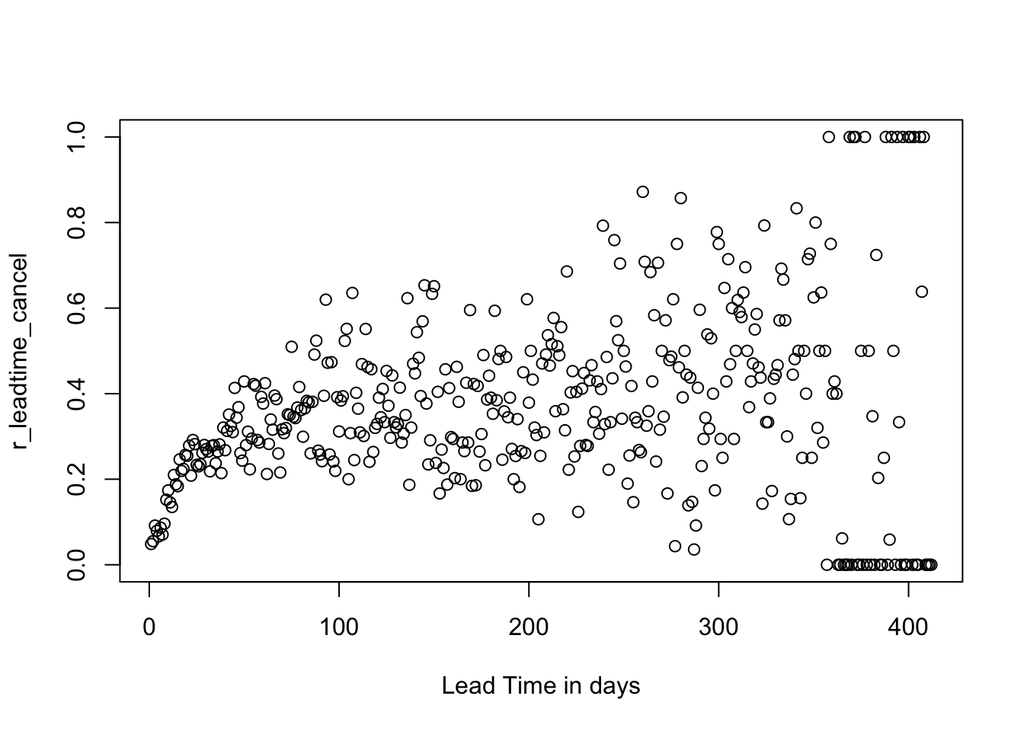

```r
r_leadtime_cancel <- tapply(rhotels$is_canceled, rhotels$lead_time, mean, na.rm = TRUE)
plot(r_leadtime_cancel, xlab = "Lead Time in days")
```

As shown in this scatter plot, there is a slight increase in the cancellation probability as the lead time increases. However, this trend also comes along with increasing variation in the cancellation probabilities, as shown by the spread of points. The least amount of variation is under 100 days of lead time. So, we can assume that, in general, a greater lead time has a greater probability of cancellation, but especially if it is under 100 days.

### **arrival_date_month**

```r
rhotels$arrival_date_month <- as.factor(rhotels$arrival_date_month)
sort(summary(rhotels$arrival_date_month), decreasing = TRUE)
```

```
##    August      July     April       May   October     March September  February
##      4894      4573      3609      3559      3555      3336      3108      3103
##      June  December  November   January
##      3045      2648      2437      2193
```

*Variable Validation: since this variable has enough variation and each month has a significant sample size, we can proceed to analyzing the cancellation rates without omitting any observations

```r
rcancelledbymonth <- tapply(rhotels$is_canceled, rhotels$arrival_date_month, mean, na.rm = TRUE)
sort(rcancelledbymonth, decreasing = TRUE)
```

```
##    August      June September      July     April       May   October  February
## 0.3344912 0.3307061 0.3236808 0.3140171 0.2934331 0.2877213 0.2751055 0.2562037
##  December     March  November   January
## 0.2382931 0.2287170 0.1891670 0.1481988
```

As shown in the table, August and June have the highest cancellation rates of about 0.33, which is about double the cancellation rates of November and January. Given this variation in cancellation rates, the hotel should definitely consider the month when calculating the probability of cancellation for each booking.

### **Stays_in_weekend_nights**

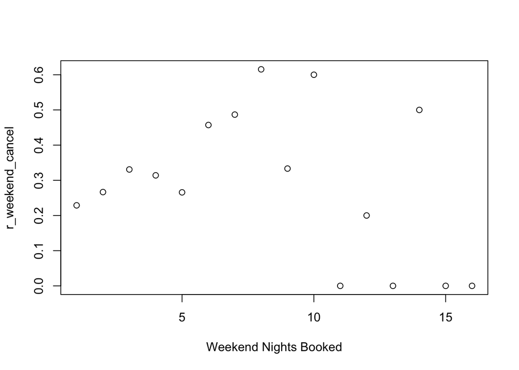

```r
r_weekend_cancel <- tapply(rhotels$is_canceled, rhotels$stays_in_weekend_nights, mean, na.rm = TRUE)
plot(r_weekend_cancel, xlab = "Weekend Nights Booked")
```

As shown in the scatter plot, the cancellation rates gradually increases to about 0.6 until about 10 weekend nights booked. After that, the cancellation rate drops to nearly 0. Given this, the hotel can assume that if there are under 10 weekend nights booked, the probability of cancellation will gradually increase up to 0.6 at most.

The average cancel rates for each number of weekend nights booked is shown in the bar graph below:

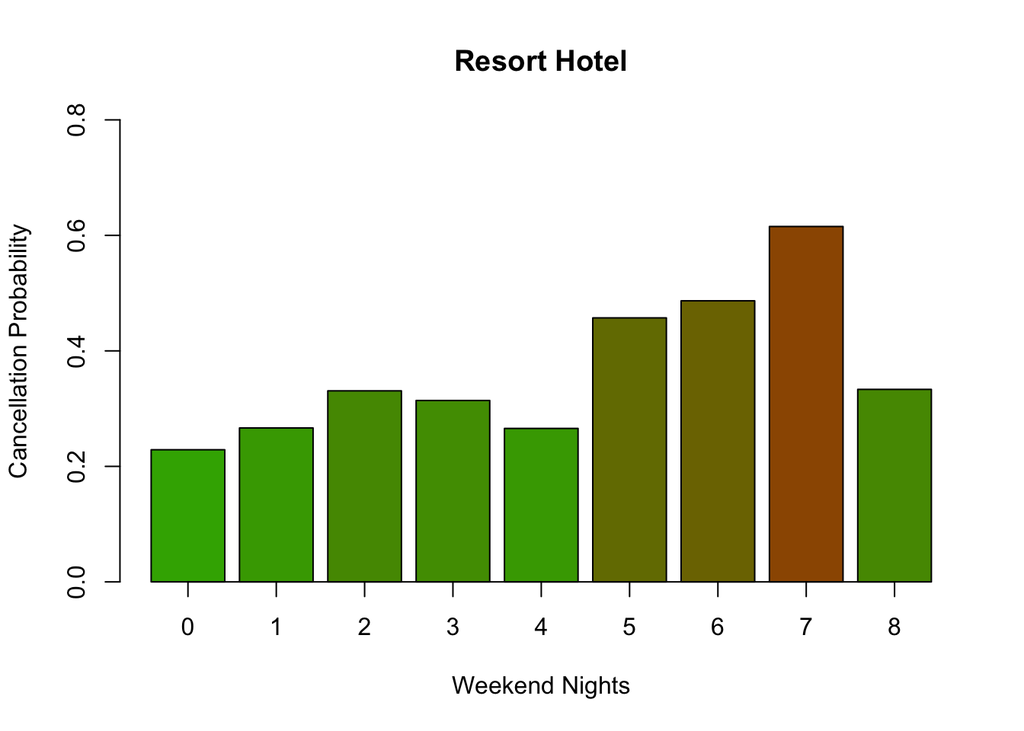

```r
weekend_cancellations_by_hotel("Resort")
```

### **Stays_in_week_nights**

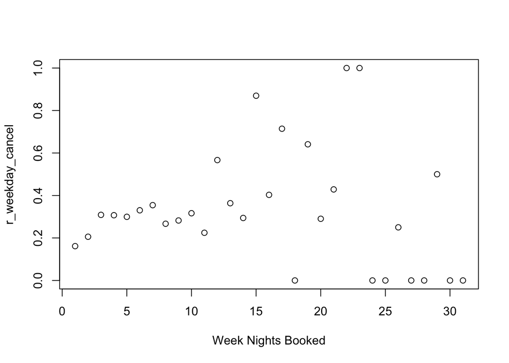

```r
r_weekday_cancel <- tapply(rhotels$is_canceled, rhotels$stays_in_week_nights, mean, na.rm = TRUE)
plot(r_weekday_cancel, xlab = "Week Nights Booked")
```

As shown in the scatter plot, the cancellation rates are generally consistent around 0.3 until about 10 week nights booked. After that, the cancellation rate varies greatly. Given this inconsistent variation in cancellation rates, the hotel does not need to consider the number of week nights booked as much when calculating the overall probability of cancellation for a booking.

The average cancel rates for each number of week nights booked is shown in the bar graph below:

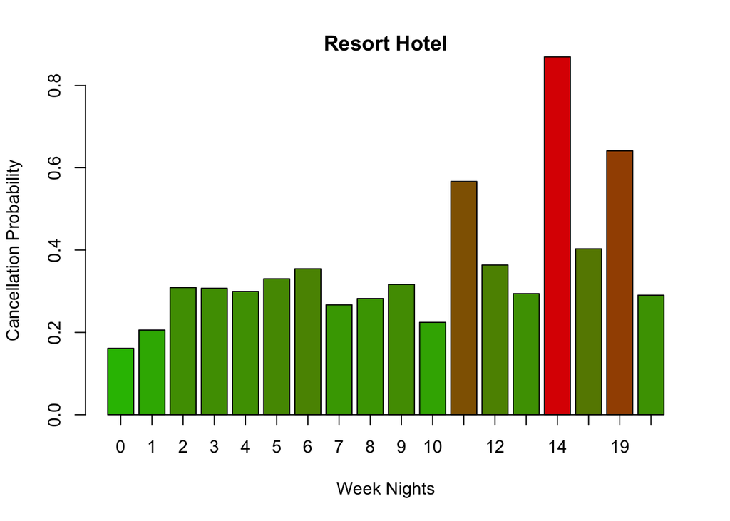

```r
weeknight_cancellations_by_hotel("Resort")
```

### **Stays in weekend and week nights**

Since many bookings include a combination of weekend and week nights, we have graphed the probability of cancellation by combining both variables:

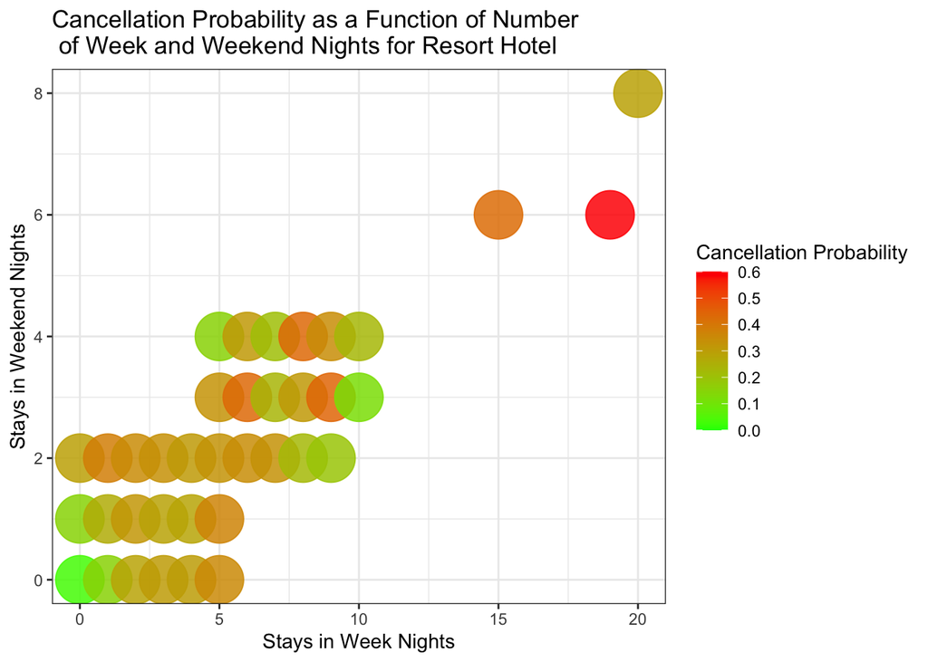

```r
week_end_colorPlot(name = "Resort Hotel")#, minNumber = 5)
```

As shown here, longer stays have higher probabilities of cancellation.

### **children**

```r
rhotels$children2 <- ifelse(rhotels$children > 0, 1, 0)
rhotels$children2 <- as.factor(rhotels$children2)
r_cancel_children <- tapply(rhotels$is_canceled, rhotels$children2, mean, na.rm = TRUE)
r_cancel_children
```

```
##         0         1
## 0.2681540 0.3771527
```

The cancellation rate for bookings without children is about 0.27 while the cancellation rate for bookings with children is about 0.38. Given this fairly large difference, the hotel should consider if there are children when calculating the probability of cancellation for a booking.

### **babies**

```r
rhotels$babies2 <- ifelse(rhotels$babies > 0, 1, 0)
rhotels$babies2 <- as.factor(rhotels$babies2)
r_cancel_babies <- tapply(rhotels$is_canceled, rhotels$babies2, mean, na.rm = TRUE)
r_cancel_babies
```

```
##         0         1
## 0.2788773 0.1879562
```

The cancellation rate for bookings without babies is about 0.28 while the cancellation rate for bookings with babies is about 0.19. Given this fairly large difference, the hotel should consider if there are babies when calculating the probability of cancellation for a booking.

### **country**

```r
rhotels$country <- as.factor(rhotels$country)
sort(summary(rhotels$country), decreasing = TRUE)
```

```
##     PRT     GBR     ESP     IRL     FRA     DEU      CN     NLD     USA    NULL
##   17630    6814    3957    2166    1611    1203     710     514     479     464
##     ITA     BEL     CHE     BRA     POL     SWE     AUT     RUS     ROU     FIN
##     459     448     435     430     333     304     210     189     177     151
##     CHN     NOR     AUS     LUX     MAR     DNK     ARG     HUN     LTU     IND
##     134     123      87      80      75      65      57      47      46      37
##     EST     LVA     ISR     CZE (Other)     AGO     TUR     UKR     ZAF     CHL
##      33      33      28      27      27      24      23      23      18      17
##     COL     PHL     NZL     GIB     DZA     SVK     TWN     ARE     GEO     HRV
##      16      16      14      13      12      12      12      11      11      11
##     OMN     SVN     GRC     MYS     NGA     JPN     KOR     PRI     CYP     URY
##      11      11      10      10      10       9       9       9       8       8
##     BLR     SRB     ISL     LBN     MDV     MEX     MOZ     THA     AND     BGR
##       7       7       6       6       6       6       6       6       5       5
##     CPV     IDN     IRN     JAM     KAZ     CUB     HKG     PAK     SGP     SUR
##       5       5       5       5       5       4       4       4       4       4
##     ALB     AZE     CAF     DOM     JEY     KWT     VEN     ARM     CIV     CMR
##       3       3       3       3       3       3       3       2       2       2
##     CRI     ECU     JOR     MLT     MWI     VNM     ZWE     BDI     BHR     BHS
##       2       2       2       2       2       2       2       1       1       1
```

*Variable Validation: though this variable has enough variation, not every country has a significant sample size. Therefore, when analyzing the cancellation rates, we will omit countries with less than 1000 bookings.

```r
sort(summary(rhotels$country), decreasing = TRUE) [1:6]
```

```
##   PRT   GBR   ESP   IRL   FRA   DEU
## 17630  6814  3957  2166  1611  1203
```

```r
rcancelledbycountry <- tapply(rhotels$is_canceled, rhotels$country, mean, na.rm = TRUE)
sort(rcancelledbycountry, decreasing = TRUE)
```

```
##        BHR        FJI        GGY        JEY        SEN        SYC        TUN
## 1.00000000 1.00000000 1.00000000 1.00000000 1.00000000 1.00000000 1.00000000
##        HKG        ARE        MDV        GEO        AND        PHL        LBN
## 0.75000000 0.72727273 0.66666667 0.63636364 0.60000000 0.56250000 0.50000000
##        MOZ        PAK        MAR        GIB        BLR        ISR        PRT
## 0.50000000 0.50000000 0.48000000 0.46153846 0.42857143 0.42857143 0.42189450
##        DZA        IDN        URY        ALB        AZE        KOR        KWT
## 0.41666667 0.40000000 0.37500000 0.33333333 0.33333333 0.33333333 0.33333333
##        VEN        LUX        RUS        TUR        AGO        ZAF        CHE
## 0.33333333 0.32500000 0.32275132 0.30434783 0.29166667 0.27777778 0.25747126
##        COL        CYP        SVK        SWE        BRA        ESP        GRC
## 0.25000000 0.25000000 0.25000000 0.24013158 0.23488372 0.21506192 0.20000000
##        KAZ        NGA        IRL        HUN        NOR        HRV        ROU
## 0.20000000 0.20000000 0.19944598 0.19148936 0.18699187 0.18181818 0.18079096
##        CHL        ITA        AUS        AUT        ARG        USA        CZE
## 0.17647059 0.17429194 0.17241379 0.16190476 0.15789474 0.15031315 0.14814815
##         CN        BEL        FRA        GBR        DEU        EST        LVA
## 0.13521127 0.13169643 0.13097455 0.13076020 0.12136326 0.12121212 0.12121212
##        POL        NLD        IND        FIN       NULL        SVN        DNK
## 0.11711712 0.10894942 0.10810811 0.10596026 0.09698276 0.09090909 0.07692308
##        CHN        LTU        ARM        BDI        BGR        BHS        BIH
## 0.06716418 0.02173913 0.00000000 0.00000000 0.00000000 0.00000000 0.00000000
##        BWA        CAF        CIV        CMR        COM        CPV        CRI
## 0.00000000 0.00000000 0.00000000 0.00000000 0.00000000 0.00000000 0.00000000
##        CUB        CYM        DJI        DOM        ECU        EGY        IRN
## 0.00000000 0.00000000 0.00000000 0.00000000 0.00000000 0.00000000 0.00000000
##        ISL        JAM        JOR        JPN        LKA        MAC        MDG
## 0.00000000 0.00000000 0.00000000 0.00000000 0.00000000 0.00000000 0.00000000
##        MEX        MKD        MLT        MUS        MWI        MYS        NPL
## 0.00000000 0.00000000 0.00000000 0.00000000 0.00000000 0.00000000 0.00000000
##        NZL        OMN        PER        PLW        PRI        QAT        SAU
## 0.00000000 0.00000000 0.00000000 0.00000000 0.00000000 0.00000000 0.00000000
##        SGP        SMR        SRB        SUR        SYR        TGO        THA
## 0.00000000 0.00000000 0.00000000 0.00000000 0.00000000 0.00000000 0.00000000
##        TWN        UGA        UKR        UZB        VNM        ZMB        ZWE
## 0.00000000 0.00000000 0.00000000 0.00000000 0.00000000 0.00000000 0.00000000
```

PRT, GBR, ESP, IRL, FRA, and DEU have cancellation rates of about 0.42, 0.13, 0.22, 0.20, 0.13, and 0.12, respectively.

This variation shows that the cancellation rates are independent from the total number of bookings, so the country of the booking should be considered when calculating the probability of cancellation (if there has been at least 1000 bookings before).

### **market_segment**

```r
rhotels$market_segment <- as.factor(rhotels$market_segment)
sort(summary(rhotels$market_segment), decreasing = TRUE)
```

```
##     Online TA Offline TA/TO        Direct        Groups     Corporate
##         17729          7472          6513          5836          2309
## Complementary
##           201
```

*Variable Validation: though this variable has enough variation, not every market segment has a significant sample size. Therefore, when analyzing the cancellation rates, we will omit market segments with less than 1000 bookings.

```r
sort(summary(rhotels$market_segment), decreasing = TRUE) [1:5]
```

```
##     Online TA Offline TA/TO        Direct        Groups     Corporate
##         17729          7472          6513          5836          2309
```

```r
rcancelledbymarket <- tapply(rhotels$is_canceled, rhotels$market_segment, mean, na.rm = TRUE)
sort(rcancelledbymarket, decreasing = TRUE)
```

```
##        Groups     Online TA Complementary Offline TA/TO     Corporate
##     0.4239205     0.3524169     0.1641791     0.1523019     0.1520139
##        Direct
##     0.1348073
```

As shown in the tables above, the Groups and Online TA market segments have significantly higher cancellation rates in comparison to other market segments. Given this variation, the hotel should consider the market segment when calculating the probability of cancellation for a booking.

### **agent**

```r
rhotels$agent <- as.factor(rhotels$agent)
sort(summary(rhotels$agent), decreasing = TRUE)
```

```
##     240    NULL     250     241      40     314     242       6      96     243
##   13905    8209    2869    1721    1002     927     779     607     537     514
##     298 (Other)     171     273     177     196     134       8     315      15
##     472     366     363     349     327     291     287     278     256     242
##      38       5     115     251      68     175     156     208     143     142
##     236     228     225     220     211     195     190     173     172     137
##     147     410     248      67     146      95      26      11       2     464
##     133     133     131     127     124     120     106     105     102      97
##     330      69     253     185     339      36      71      75     531     281
##      91      88      87      78      77      71      71      70      68      64
##     385     181     155     440     332       1     308     184     152     249
##      60      59      58      56      55      54      54      52      51      51
##     495     468     436     127     183     305     368     201     168      66
##      50      49      47      45      45      45      45      42      40      39
##     261     245     375     313     493     527     306     434     387     479
##      38      37      37      36      35      35      34      33      32      32
##      94     149       3     334     350     492     467     252      91     257
##      29      28      28      28      28      28      27      26      26      24
##      47     502     256     336     348     310      57      88     104     223
##      24      24      23      23      22      20      20      19      18      18
```

*Variable Validation: though this variable has enough variation, not every agent has a significant sample size. Therefore, when analyzing the cancellation rates, we will omit agents with less than 1000 bookings.

```r
sort(summary(rhotels$agent), decreasing = TRUE) [1:5]
```

```
##   240  NULL   250   241    40
## 13905  8209  2869  1721  1002
```

```r
rcancelledbyagent <- tapply(rhotels$is_canceled, rhotels$agent, mean, na.rm = TRUE)
sort(rcancelledbyagent, decreasing = TRUE)
```

```
##        252        257        291        310        390        472        483
## 1.00000000 1.00000000 1.00000000 1.00000000 1.00000000 1.00000000 1.00000000
##        492        495          1         68        281        332        155
## 1.00000000 1.00000000 0.92592593 0.78199052 0.78125000 0.74545455 0.74137931
##         11        245        440        531        248        134        249
## 0.71428571 0.70270270 0.67857143 0.67647059 0.63358779 0.61672474 0.60784314
##         67        305         38         71        208         29        307
## 0.59842520 0.57777778 0.55932203 0.54929577 0.54913295 0.50000000 0.50000000
##         96        315        240         15        368        348        149
## 0.45437616 0.39843750 0.39431859 0.38429752 0.37777778 0.36363636 0.35714286
##        410        273        242        110        183        420          9
## 0.35338346 0.34670487 0.33376123 0.33333333 0.33333333 0.33333333 0.33333333
##        142        298        105        385        181        375        195
## 0.32846715 0.30084746 0.28571429 0.28333333 0.27118644 0.27027027 0.25000000
##        244        275        175        177        147         10        327
## 0.25000000 0.25000000 0.24615385 0.23853211 0.23308271 0.23076923 0.22222222
##        184        261          5        326        405        429        196
## 0.21153846 0.21052632 0.20614035 0.20000000 0.20000000 0.20000000 0.19587629
##        339        250        314       NULL        253        154        468
## 0.19480519 0.17880795 0.17583603 0.17310269 0.17241379 0.16666667 0.16326531
##         95        393         66        126          3        493          8
## 0.15833333 0.15384615 0.15384615 0.14285714 0.14285714 0.14285714 0.14028777
##        241        171         75        139        481        185        324
## 0.13712958 0.13498623 0.12857143 0.12500000 0.12500000 0.11538462 0.11111111
##        156        526         57        143          6        251        387
## 0.11052632 0.10000000 0.10000000 0.09883721 0.09719934 0.09545455 0.09375000
##        146        256        336        436         26         40        152
## 0.08870968 0.08695652 0.08695652 0.08510638 0.08490566 0.08183633 0.07843137
##        128         36          2        411        434        306        313
## 0.07692308 0.07042254 0.06862745 0.06250000 0.06060606 0.05882353 0.05555556
##        243        115        168        127         91        308        334
## 0.05447471 0.05333333 0.05000000 0.04444444 0.03846154 0.03703704 0.03571429
##         94         69        201        330        464        104        114
## 0.03448276 0.03409091 0.02380952 0.02197802 0.01030928 0.00000000 0.00000000
##        135        159         16        163        165        167        180
## 0.00000000 0.00000000 0.00000000 0.00000000 0.00000000 0.00000000 0.00000000
##        182        187        193        223        254        258        270
## 0.00000000 0.00000000 0.00000000 0.00000000 0.00000000 0.00000000 0.00000000
##        282        300        301        302        303        304        321
## 0.00000000 0.00000000 0.00000000 0.00000000 0.00000000 0.00000000 0.00000000
##        328        331        333        335        337         34        350
## 0.00000000 0.00000000 0.00000000 0.00000000 0.00000000 0.00000000 0.00000000
##        352        355        358        360        363        367        384
## 0.00000000 0.00000000 0.00000000 0.00000000 0.00000000 0.00000000 0.00000000
##        406        414        418        426        427        430        431
## 0.00000000 0.00000000 0.00000000 0.00000000 0.00000000 0.00000000 0.00000000
##        432        433        438        441        446        450        451
## 0.00000000 0.00000000 0.00000000 0.00000000 0.00000000 0.00000000 0.00000000
##        454        455        467        469         47        476        479
## 0.00000000 0.00000000 0.00000000 0.00000000 0.00000000 0.00000000 0.00000000
##        497        502        508        510        527        535         59
## 0.00000000 0.00000000 0.00000000 0.00000000 0.00000000 0.00000000 0.00000000
##         64         72         78         88
## 0.00000000 0.00000000 0.00000000 0.00000000
```

Agents 240, 250, 241, and 40 have cancellation rates of about 0.39, 0.18, 0.14, and 0.08, respectively.

This variation shows that the cancellation rates are independent from the total number of bookings, so the agent of the booking should be considered when calculating the probability of cancellation (if there has been at least 1000 bookings before).

### **total_of_special_requests**

```r
rhotels$total_of_special_requests <- as.factor(rhotels$total_of_special_requests)
sort(summary(rhotels$total_of_special_requests), decreasing = TRUE)
```

```
##     0     1     2     3     4     5
## 22361 11806  4827   910   142    14
```

*Variable Validation: though this variable has enough variation, not every number has a significant sample size. Therefore, when analyzing the cancellation rates, we will omit numbers with less than 1000 bookings.

```r
sort(summary(rhotels$total_of_special_requests), decreasing = TRUE) [1:3]
```

```
##     0     1     2
## 22361 11806  4827
```

```r
rcancelledbyrequest <- tapply(rhotels$is_canceled, rhotels$total_of_special_requests, mean, na.rm = TRUE)
sort(rcancelledbyrequest, decreasing = TRUE)
```

```
##          0          2          1          3          4          5
## 0.32270471 0.23347835 0.21997290 0.18241758 0.10563380 0.07142857
```

As shown in the table above, as the number of special requests increase, the cancellation rate slightly decreases. However, since there is not much variation between the cancellation rates overall, this does not need to be considered when calculating the probability of cancellation for a booking.

## City Hotel

### **Lead_time**

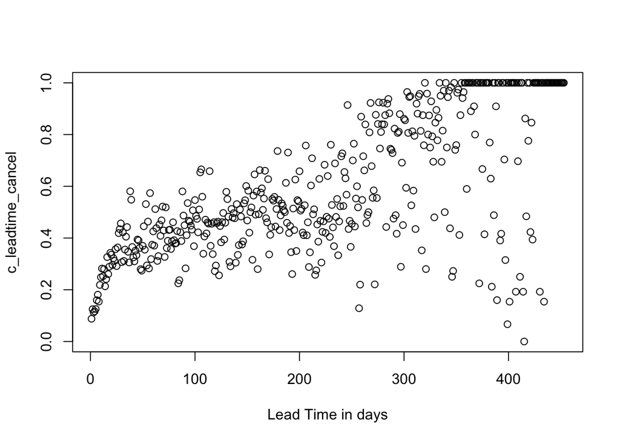

```r
c_leadtime_cancel <- tapply(chotels$is_canceled, chotels$lead_time, mean, na.rm = TRUE)
plot(c_leadtime_cancel, xlab = "Lead Time in days")
```

As shown in this scatter plot, there is a significant increase in the cancellation probability as the lead time increases. Though there is some variation, the overall trend is quite strong. Overall, we can assume that a greater lead time has a greater probability of cancellation.

### **arrival_date_month**

```r
chotels$arrival_date_month <- as.factor(chotels$arrival_date_month)
sort(summary(chotels$arrival_date_month), decreasing = TRUE)
```

```
##    August       May      July      June   October     April September     March
##      8983      8232      8088      7894      7605      7480      7400      6458
##  February  November  December   January
##      4965      4357      4132      3736
```

*Variable Validation: since this variable has enough variation and each month has a significant sample size, we can proceed to analyzing the cancellation rates without omitting any observations

```r
ccancelledbymonth <- tapply(chotels$is_canceled, chotels$arrival_date_month, mean, na.rm = TRUE)
sort(ccancelledbymonth, decreasing = TRUE)
```

```
##     April      June       May   October  December September      July    August
## 0.4632353 0.4469217 0.4437561 0.4297173 0.4211036 0.4202703 0.4087537 0.4009796
##   January  February  November     March
## 0.3966809 0.3828802 0.3812256 0.3694642
```

As shown in the table, April has the highest cancellation rate of about 0.46 while March has the lowest cancellation rate of about 0.37, which is only a 0.10 difference. Given that the cancellation rates do not vary greatly between any of the months, the hotel does not need to consider the month of a booking as much when calculating its overall probability of cancellation.

### **Stays_in_weekend_nights**

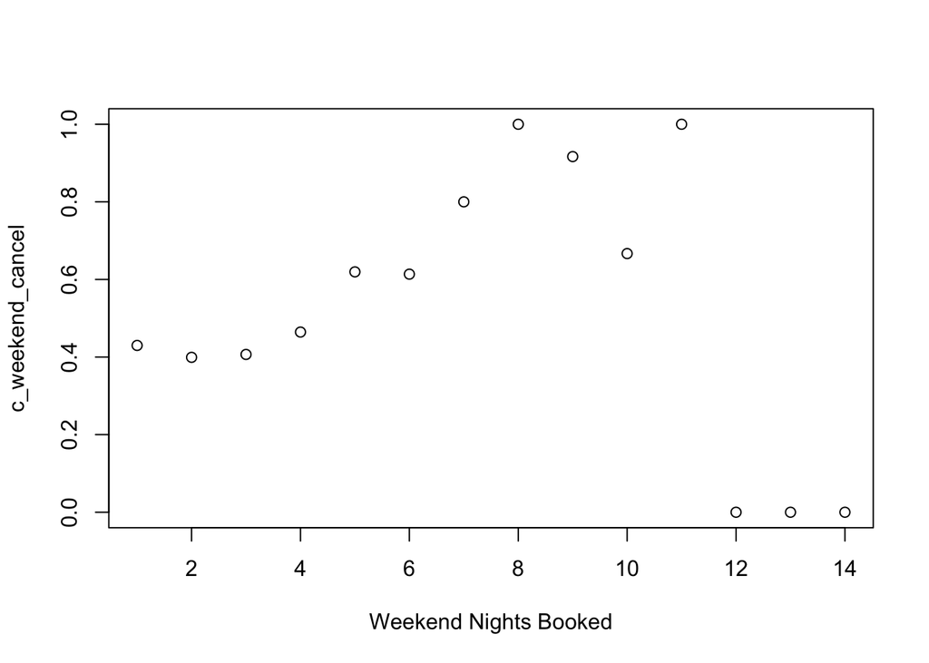

```r
c_weekend_cancel <- tapply(chotels$is_canceled, chotels$stays_in_weekend_nights, mean, na.rm = TRUE)
plot(c_weekend_cancel, xlab = "Weekend Nights Booked")
```

The average cancel rates for each number of weekend nights booked is shown in the bar graph below:

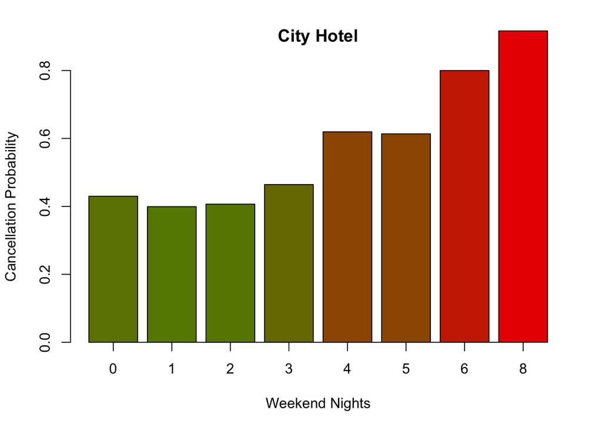

```r
weekend_cancellations_by_hotel("City")
```

### **Stays_in_week_nights**

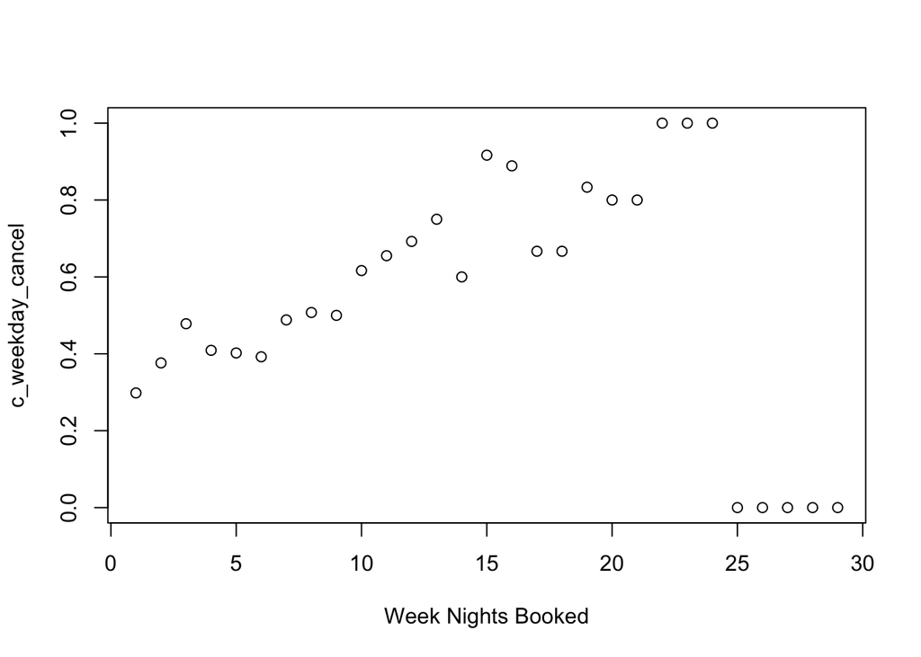

```r
c_weekday_cancel <- tapply(chotels$is_canceled, chotels$stays_in_week_nights, mean, na.rm = TRUE)
plot(c_weekday_cancel, xlab = "Week Nights Booked")
```

As shown in the scatter plot, the cancellation rates increases until about 25 week nights booked. After that, the cancellation rate drops to nearly 0. Given this, the hotel can assume that if there are under 25 week nights booked, the probability of cancellation will gradually increase.

The average cancel rates for each number of week nights booked is shown in the bar graph below:

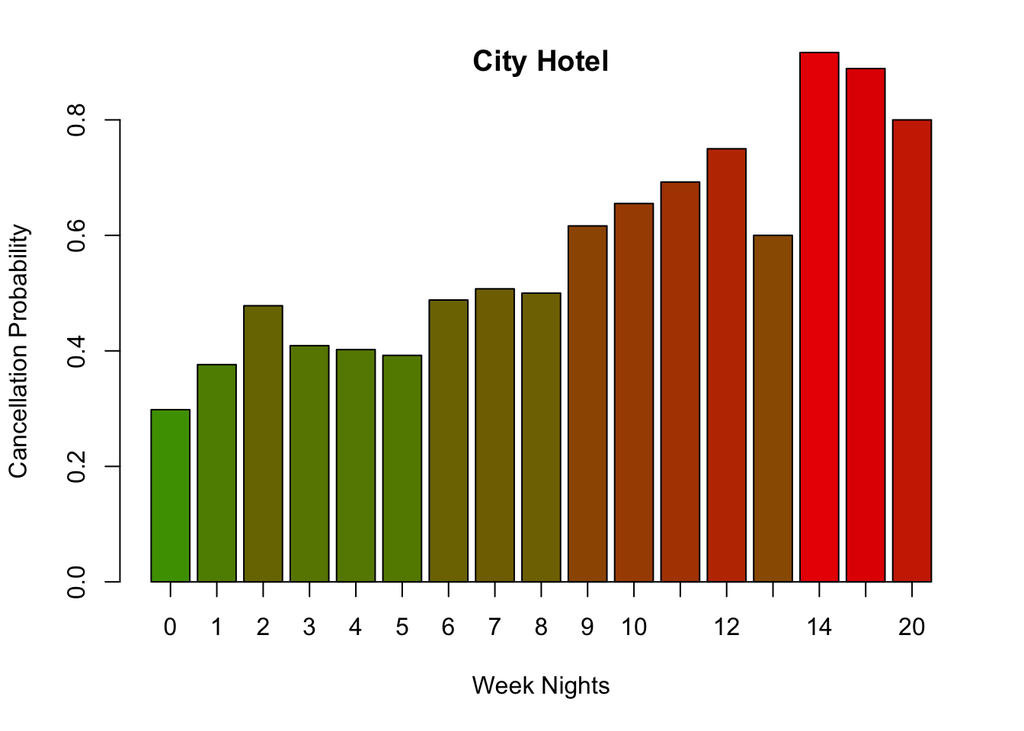

```r
weeknight_cancellations_by_hotel("City")
```

### **Stays in weekend and week nights**

Since many bookings include a combination of weekend and week nights, we have graphed the probability of cancellation by combining both variables:

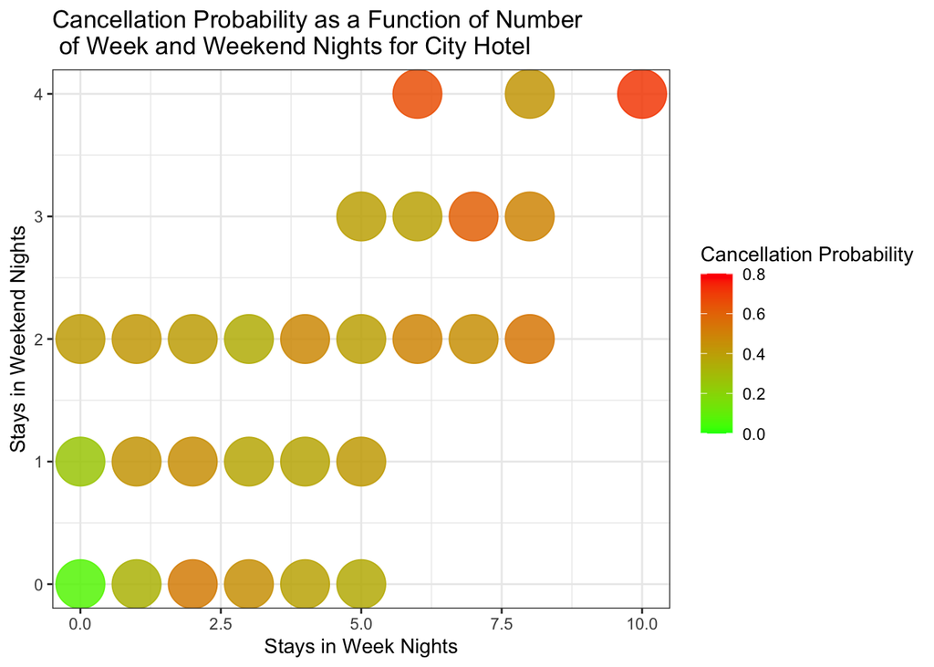

```r
week_end_colorPlot(name = "City Hotel")#, minNumber = 5)
```

As shown here, longer stays have higher probabilities of cancellation.

### **children**

```r
chotels$children2 <- ifelse(chotels$children > 0, 1, 0)
chotels$children2 <- as.factor(chotels$children2)
c_cancel_children <- tapply(chotels$is_canceled, chotels$children2, mean, na.rm = TRUE)
c_cancel_children
```

```
##         0         1
## 0.4215306 0.3548766
```

The cancellation rate for bookings without children is about 0.42 while the cancellation rate for bookings with children is about 0.35. Given this fairly large difference, the hotel should consider if there are children when calculating the probability of cancellation for a booking.

### **babies**

```r
chotels$babies2 <- ifelse(chotels$babies > 0, 1, 0)
chotels$babies2 <- as.factor(chotels$babies2)
c_cancel_babies <- tapply(chotels$is_canceled, chotels$babies2, mean, na.rm = TRUE)
c_cancel_babies
```

```
##         0         1
## 0.4184091 0.1734417
```

The cancellation rate for bookings without babies is about 0.42 while the cancellation rate for bookings with babies is about 0.17. Given this significantly large difference, the hotel should consider if there are babies when calculating the probability of cancellation for a booking.

### **country**

```r
chotels$country <- as.factor(chotels$country)
sort(summary(chotels$country), decreasing = TRUE)
```

```
##     PRT     FRA     DEU     GBR     ESP     ITA     BEL     BRA     USA     NLD
##   30960    8804    6084    5315    4611    3307    1894    1794    1618    1590
##     CHE     IRL     AUT     CHN     SWE     ISR     POL      CN     NOR     RUS
##    1295    1209    1053     865     720     641     586     569     484     443
##     DNK     AUS     AGO     ROU     FIN     TUR     LUX     JPN     MAR     HUN
##     370     339     338     323     296     225     207     188     184     183
## (Other)     ARG     CZE     KOR     GRC     IND     SRB     DZA     HRV     MEX
##     168     157     144     124     118     115      94      91      89      79
##     IRN     BGR     ZAF     MOZ     NZL     COL     SVK     THA     ISL     EST
##      78      70      62      61      60      55      53      53      51      50
##     CHL     SAU     SVN     UKR     CYP     ARE     TWN     TUN     LTU     SGP
##      48      47      46      45      43      40      39      38      35      35
##     EGY     IDN     PER     ECU     HKG     LBN     NGA    NULL     PHL     URY
##      31      30      28      25      25      25      24      24      24      24
##     VEN     LVA     BLR     CPV     JOR     MYS     CRI     MLT     MAC     AZE
##      23      22      19      19      19      18      17      16      15      14
##     IRQ     KAZ     QAT     KWT     BGD     BIH     DOM     GEO     BOL     PAK
##      14      14      14      13      12      12      11      11      10      10
##     SEN     ALB     GNB     MKD     PAN     TJK     CMR     LBY     OMN     ARM
##      10       9       9       9       9       9       8       8       7       6
```

*Variable Validation: though this variable has enough variation, not every country has a significant sample size. Therefore, when analyzing the cancellation rates, we will omit countries with less than 1000 bookings.

```r
sort(summary(chotels$country), decreasing = TRUE) [1:13]
```

```
##   PRT   FRA   DEU   GBR   ESP   ITA   BEL   BRA   USA   NLD   CHE   IRL   AUT
## 30960  8804  6084  5315  4611  3307  1894  1794  1618  1590  1295  1209  1053
```

```r
ccancelledbycountry <- tapply(chotels$is_canceled, chotels$country, mean, na.rm = TRUE)
sort(ccancelledbycountry, decreasing = TRUE)
```

```
##        AND        BEN        GGY        GIB        GLP        HND        IMN
## 1.00000000 1.00000000 1.00000000 1.00000000 1.00000000 1.00000000 1.00000000
##        JEY        KHM        MAC        MYT        NIC        UMI        VGB
## 1.00000000 1.00000000 1.00000000 1.00000000 1.00000000 1.00000000 1.00000000
##        ZMB        ZWE        HKG       NULL        TJK        ARE        MDV
## 1.00000000 1.00000000 0.92000000 0.91666667 0.88888889 0.87500000 0.83333333
##        FRO        NGA        QAT        BGD        BHR        IDN        DOM
## 0.80000000 0.79166667 0.78571429 0.75000000 0.75000000 0.73333333 0.72727273
##        GEO        SAU        PAK        SEN        PHL        PRI        UZB
## 0.72727273 0.70212766 0.70000000 0.70000000 0.66666667 0.66666667 0.66666667
##        PRT        CPV        TZA        AGO        AZE        OMN        CHN
## 0.64861111 0.63157895 0.60000000 0.58579882 0.57142857 0.57142857 0.52369942
##        CIV        GAB        GHA        VEN        TUN        SGP        UKR
## 0.50000000 0.50000000 0.50000000 0.47826087 0.47368421 0.45714286 0.44444444
##        TUR        KOR        ZAF        BRA        RUS        LUX        MNE
## 0.42222222 0.41935484 0.41935484 0.40635452 0.40180587 0.40096618 0.40000000
##        MAR        SVK        KWT        ITA        HUN        TWN        EGY
## 0.39673913 0.39622642 0.38461538 0.37889326 0.37158470 0.35897436 0.35483871
##        COL        THA        ARM        ETH        KEN        LIE        TMP
## 0.34545455 0.33962264 0.33333333 0.33333333 0.33333333 0.33333333 0.33333333
##        VNM        IRL        NOR        ECU        BLR        ROU        MLT
## 0.33333333 0.33085194 0.32644628 0.32000000 0.31578947 0.31578947 0.31250000
##        SVN        POL        IRN        GBR        ESP        ARG        KAZ
## 0.30434783 0.30034130 0.29487179 0.29388523 0.28757319 0.28662420 0.28571429
##        DNK        EST        GRC         CN        AUS        CHL        IND
## 0.28108108 0.28000000 0.27966102 0.27768014 0.27138643 0.27083333 0.26956522
##        USA        MOZ        HRV        BIH        MCO        URY        ISR
## 0.26514215 0.26229508 0.25842697 0.25000000 0.25000000 0.25000000 0.24492980
##        CHE        LBN        CZE        LVA        MKD        BEL        PER
## 0.24401544 0.24000000 0.22916667 0.22727273 0.22222222 0.21911299 0.21428571
##        SWE        CYP        NLD        FRA        AUT        FIN        DEU
## 0.21388889 0.20930233 0.20817610 0.19570650 0.18613485 0.17905405 0.17619987
##        DZA        BGR        LTU        MUS        MYS        JOR        JPN
## 0.17582418 0.17142857 0.17142857 0.16666667 0.16666667 0.15789474 0.14893617
##        MEX        ALB        GNB        NZL        ISL        CRI        SRB
## 0.12658228 0.11111111 0.11111111 0.10000000 0.07843137 0.05882353 0.03191489
##        ABW        AIA        ASM        ATA        ATF        BFA        BOL
## 0.00000000 0.00000000 0.00000000 0.00000000 0.00000000 0.00000000 0.00000000
##        BRB        CAF        CMR        COM        CUB        DMA        GTM
## 0.00000000 0.00000000 0.00000000 0.00000000 0.00000000 0.00000000 0.00000000
##        GUY        IRQ        JAM        KIR        KNA        LAO        LBY
## 0.00000000 0.00000000 0.00000000 0.00000000 0.00000000 0.00000000 0.00000000
##        LCA        LKA        MLI        MMR        MRT        NAM        NCL
## 0.00000000 0.00000000 0.00000000 0.00000000 0.00000000 0.00000000 0.00000000
##        PAN        PRY        PYF        RWA        SDN        SLE        SLV
## 0.00000000 0.00000000 0.00000000 0.00000000 0.00000000 0.00000000 0.00000000
##        STP        SUR        SYC        SYR        TGO        UGA
## 0.00000000 0.00000000 0.00000000 0.00000000 0.00000000 0.00000000
```

The countries with the highest number of bookings are PRT, FRA, DEU, GBR, and ESP, and their cancellation rates are about 0.65, 0.20, 0.18, 0.29, and 0.29, respectively.

This variation shows that the cancellation rates are independent from the total number of bookings, so the country of the booking should be considered when calculating the probability of cancellation (if there has been at least 1000 bookings before).

### **market_segment**

```r
chotels$market_segment <- as.factor(chotels$market_segment)
sort(summary(chotels$market_segment), decreasing = TRUE)
```

```
##     Online TA Offline TA/TO        Groups        Direct     Corporate
##         38748         16747         13975          6093          2986
## Complementary      Aviation     Undefined
##           542           237             2
```

*Variable Validation: though this variable has enough variation, not every market segment has a significant sample size. Therefore, when analyzing the cancellation rates, we will omit market segments with less than 1000 bookings.

```r
sort(summary(chotels$market_segment), decreasing = TRUE) [1:5]
```

```
##     Online TA Offline TA/TO        Groups        Direct     Corporate
##         38748         16747         13975          6093          2986
```

```r
ccancelledbymarket <- tapply(chotels$is_canceled, chotels$market_segment, mean, na.rm = TRUE)
sort(ccancelledbymarket, decreasing = TRUE)
```

```
##     Undefined        Groups Offline TA/TO     Online TA      Aviation
##     1.0000000     0.6885868     0.4283155     0.3739806     0.2194093
##     Corporate        Direct Complementary
##     0.2146685     0.1733136     0.1180812
```

As shown in the tables above, the Groups, Offline TA/TO, and Online TA market segments have significantly higher cancellation rates in comparison to other market segments. Given this variation, the hotel should consider the market segment when calculating the probability of cancellation for a booking.

### **agent**

```r
chotels$agent <- as.factor(chotels$agent)
sort(summary(chotels$agent), decreasing = TRUE)
```

```
##       9    NULL       1      14       7       6      28       3       8      37
##   31955    8131    7137    3640    3539    2683    1666    1308    1236    1230
##      19      21 (Other)     229      83      29      12      85      20      30
##    1061     875     854     786     696     679     578     554     540     484
##      27      22      56      86      58     119      26      34      44      11
##     450     382     375     338     335     304     295     293     292     290
##     138      10     236     171      16      17      42     191     134     195
##     287     247     247     244     242     241     211     198     195     189
##     154      31      15     326     168     132      52     152     234      39
##     187     162     160     160     144     143     137     132     128     127
##      98      35     220       5      89     170     159      94      13      82
##     124     109     104     102      99      93      88      85      82      77
##      87      41     118      99     157       2     133     151     390       4
##      77      75      69      68      61      60      56      56      56      47
##      79     286     296     192      38     121     162      40     155     378
##      47      45      42      41      38      37      37      37      36      36
##     104     330     394      77      45      91      33     173     235      36
##      35      34      33      33      32      32      31      29      29      29
##      63      78     315     205      47     153      23     254     323     147
##      29      29      28      27      26      25      25      25      25      23
```

*Variable Validation: though this variable has enough variation, not every agent has a significant sample size. Therefore, when analyzing the cancellation rates, we will omit agents with less than 1000 bookings.

```r
sort(summary(chotels$agent), decreasing = TRUE) [1:11]
```

```
##     9  NULL     1    14     7     6    28     3     8    37    19
## 31955  8131  7137  3640  3539  2683  1666  1308  1236  1230  1061
```

```r
ccancelledbyagent <- tapply(chotels$is_canceled, chotels$agent, mean, na.rm = TRUE)
sort(ccancelledbyagent, decreasing = TRUE)
```

```
##         107         162         170         235         236         270
## 1.000000000 1.000000000 1.000000000 1.000000000 1.000000000 1.000000000
##         276         286         287         323         326         331
## 1.000000000 1.000000000 1.000000000 1.000000000 1.000000000 1.000000000
##         403          41          47           5          55          60
## 1.000000000 1.000000000 1.000000000 1.000000000 1.000000000 1.000000000
##          64          78          93          31          58          57
## 1.000000000 1.000000000 1.000000000 0.950617284 0.880597015 0.875000000
##         182         192          33          29          44          53
## 0.857142857 0.829268293 0.806451613 0.801178203 0.794520548 0.777777778
##         378          19           1         154         119          56
## 0.750000000 0.735155514 0.732800897 0.721925134 0.694078947 0.682666667
##         133         355          20           4         134         229
## 0.678571429 0.666666667 0.664814815 0.659574468 0.625641026 0.615776081
##          34         214          35           3          37          86
## 0.610921502 0.600000000 0.596330275 0.586391437 0.582926829 0.582840237
##          21         296          82          12         147         191
## 0.578285714 0.571428571 0.545454545 0.525951557 0.521739130 0.520202020
##         151         171         179         341          71          98
## 0.517857143 0.504098361 0.500000000 0.500000000 0.500000000 0.491935484
##          17          87           2           9          26         118
## 0.477178423 0.467532468 0.450000000 0.415021123 0.413559322 0.405797101
##          50          66         234          30          99         262
## 0.400000000 0.400000000 0.398437500 0.390495868 0.382352941 0.363636364
##           6          39          75        NULL           8         132
## 0.360044726 0.354330709 0.333333333 0.320870742 0.313915858 0.307692308
##          13         254          52          83         155          10
## 0.304878049 0.280000000 0.277372263 0.271551724 0.250000000 0.246963563
##         153         509          94          85         390         195
## 0.240000000 0.200000000 0.200000000 0.198555957 0.196428571 0.195767196
##         425          14         330          15         281          81
## 0.187500000 0.179120879 0.176470588 0.175000000 0.166666667 0.166666667
##         290          38          45         219         177          79
## 0.157894737 0.157894737 0.156250000 0.153846154 0.150000000 0.148936170
##         205         104         210          42         174         138
## 0.148148148 0.142857143 0.142857143 0.137440758 0.136363636 0.135888502
##           7         157         111          22          11         173
## 0.133936140 0.131147541 0.125000000 0.117801047 0.103448276 0.103448276
##         159         128          27         103         484         168
## 0.102272727 0.100000000 0.100000000 0.095238095 0.090909091 0.090277778
```

[output cut: 21 more lines]

```
## 0.000000000 0.000000000 0.000000000 0.000000000 0.000000000 0.000000000
##          36         364         370         371         375         388
## 0.000000000 0.000000000 0.000000000 0.000000000 0.000000000 0.000000000
##         391         397         404         408         416         427
## 0.000000000 0.000000000 0.000000000 0.000000000 0.000000000 0.000000000
##         436         441         444         449         453         455
## 0.000000000 0.000000000 0.000000000 0.000000000 0.000000000 0.000000000
##         459         461         464         467         474         475
## 0.000000000 0.000000000 0.000000000 0.000000000 0.000000000 0.000000000
##         476         480         495          54          61          63
## 0.000000000 0.000000000 0.000000000 0.000000000 0.000000000 0.000000000
##          69          70          72          73          74          90
## 0.000000000 0.000000000 0.000000000 0.000000000 0.000000000 0.000000000
##          92          95
## 0.000000000 0.000000000
```

The agents with the highest number of bookings are 9, 1, and 14, and their cancellation rates are about 0.42, 0.73, and 0.18, respectively.

This variation shows that the cancellation rates are independent from the total number of bookings, so the agent of the booking should be considered when calculating the probability of cancellation (if there has been at least 1000 bookings before).

### **total_of_special_requests**

```r
chotels$total_of_special_requests <- as.factor(chotels$total_of_special_requests)
sort(summary(chotels$total_of_special_requests), decreasing = TRUE)
```

```
##     0     1     2     3     4     5
## 47957 21420  8142  1587   198    26
```

*Variable Validation: though this variable has enough variation, not every number has a significant sample size. Therefore, when analyzing the cancellation rates, we will omit numbers with less than 1000 bookings.

```r
sort(summary(chotels$total_of_special_requests), decreasing = TRUE) [1:4]
```

```
##     0     1     2     3
## 47957 21420  8142  1587
```

```r
ccancelledbyrequest <- tapply(chotels$is_canceled, chotels$total_of_special_requests, mean, na.rm = TRUE)
sort(ccancelledbyrequest, decreasing = TRUE)
```

```
##          0          1          2          3          4          5
## 0.54924203 0.22040149 0.21358389 0.17643352 0.10606061 0.03846154
```

As shown in the table above, as the number of special requests increase, the cancellation rate decreases significantly, so this should be considered when calculating the probability of cancellation for a booking.